# Risk Factor Analysis

## Outcome Variable

**Outcome Variable:** y_rate_wtkg

## Predictor Variables

**Intervention Variable:** safeh20

**Adjustment Set:**

- arm
- sex
- W_mage
- meducyrs
- feducyrs
- hhwealth_quart
- hfoodsec
- W_mhtcm
- W_mwtkg
- W_mbmi
- W_nrooms
- W_nchldlt5
- impfloor
- impsan
- delta_W_mage
- delta_meducyrs
- delta_feducyrs
- delta_hhwealth_quart
- delta_hfoodsec
- delta_W_mhtcm
- delta_W_mwtkg
- delta_W_mbmi
- delta_W_nrooms
- delta_W_nchldlt5
- delta_impfloor
- delta_impsan

## Stratifying Variables

The analysis was stratified on these variable(s):

- agecat
- studyid
- country

## Data Summary

| agecat | studyid | country | safeh20 | n_cell | n | outcome_variable |
| --- | --- | --- | --- | --- | --- | --- |
| 0-3 months | ki0047075b-MAL-ED | BANGLADESH | 1 | 0 | 239 | y_rate_wtkg |
| 0-3 months | ki0047075b-MAL-ED | BANGLADESH | 0 | 239 | 239 | y_rate_wtkg |
| 0-3 months | ki0047075b-MAL-ED | BRAZIL | 1 | 0 | 142 | y_rate_wtkg |
| 0-3 months | ki0047075b-MAL-ED | BRAZIL | 0 | 142 | 142 | y_rate_wtkg |
| 0-3 months | ki0047075b-MAL-ED | INDIA | 1 | 0 | 232 | y_rate_wtkg |
| 0-3 months | ki0047075b-MAL-ED | INDIA | 0 | 232 | 232 | y_rate_wtkg |
| 0-3 months | ki0047075b-MAL-ED | NEPAL | 1 | 1 | 227 | y_rate_wtkg |
| 0-3 months | ki0047075b-MAL-ED | NEPAL | 0 | 226 | 227 | y_rate_wtkg |
| 0-3 months | ki0047075b-MAL-ED | PERU | 1 | 11 | 258 | y_rate_wtkg |
| 0-3 months | ki0047075b-MAL-ED | PERU | 0 | 247 | 258 | y_rate_wtkg |
| 0-3 months | ki0047075b-MAL-ED | SOUTH AFRICA | 1 | 38 | 251 | y_rate_wtkg |
| 0-3 months | ki0047075b-MAL-ED | SOUTH AFRICA | 0 | 213 | 251 | y_rate_wtkg |
| 0-3 months | ki0047075b-MAL-ED | TANZANIA, UNITED REPUBLIC OF | 1 | 158 | 232 | y_rate_wtkg |
| 0-3 months | ki0047075b-MAL-ED | TANZANIA, UNITED REPUBLIC OF | 0 | 74 | 232 | y_rate_wtkg |
| 0-3 months | ki1017093-NIH-Birth | BANGLADESH | 1 | 563 | 565 | y_rate_wtkg |
| 0-3 months | ki1017093-NIH-Birth | BANGLADESH | 0 | 2 | 565 | y_rate_wtkg |
| 0-3 months | ki1017093b-PROVIDE | BANGLADESH | 1 | 13 | 13 | y_rate_wtkg |
| 0-3 months | ki1017093b-PROVIDE | BANGLADESH | 0 | 0 | 13 | y_rate_wtkg |
| 0-3 months | ki1017093c-NIH-Crypto | BANGLADESH | 1 | 725 | 725 | y_rate_wtkg |
| 0-3 months | ki1017093c-NIH-Crypto | BANGLADESH | 0 | 0 | 725 | y_rate_wtkg |
| 0-3 months | ki1114097-CONTENT | PERU | 1 | 5 | 6 | y_rate_wtkg |
| 0-3 months | ki1114097-CONTENT | PERU | 0 | 1 | 6 | y_rate_wtkg |
| 0-3 months | kiGH5241-JiVitA-3 | BANGLADESH | 1 | 20239 | 20272 | y_rate_wtkg |
| 0-3 months | kiGH5241-JiVitA-3 | BANGLADESH | 0 | 33 | 20272 | y_rate_wtkg |
| 0-3 months | kiGH5241-JiVitA-4 | BANGLADESH | 1 | 2496 | 2496 | y_rate_wtkg |
| 0-3 months | kiGH5241-JiVitA-4 | BANGLADESH | 0 | 0 | 2496 | y_rate_wtkg |
| 3-6 months | ki0047075b-MAL-ED | BANGLADESH | 1 | 0 | 233 | y_rate_wtkg |
| 3-6 months | ki0047075b-MAL-ED | BANGLADESH | 0 | 233 | 233 | y_rate_wtkg |
| 3-6 months | ki0047075b-MAL-ED | BRAZIL | 1 | 0 | 141 | y_rate_wtkg |
| 3-6 months | ki0047075b-MAL-ED | BRAZIL | 0 | 141 | 141 | y_rate_wtkg |

[output cut: 182 more lines]

The following strata were considered:

- agecat: 0-3 months, studyid: ki0047075b-MAL-ED, country: BANGLADESH
- agecat: 0-3 months, studyid: ki0047075b-MAL-ED, country: BRAZIL
- agecat: 0-3 months, studyid: ki0047075b-MAL-ED, country: INDIA
- agecat: 0-3 months, studyid: ki0047075b-MAL-ED, country: NEPAL
- agecat: 0-3 months, studyid: ki0047075b-MAL-ED, country: PERU
- agecat: 0-3 months, studyid: ki0047075b-MAL-ED, country: SOUTH AFRICA
- agecat: 0-3 months, studyid: ki0047075b-MAL-ED, country: TANZANIA, UNITED REPUBLIC OF
- agecat: 0-3 months, studyid: ki1017093-NIH-Birth, country: BANGLADESH
- agecat: 0-3 months, studyid: ki1017093b-PROVIDE, country: BANGLADESH
- agecat: 0-3 months, studyid: ki1017093c-NIH-Crypto, country: BANGLADESH
- agecat: 0-3 months, studyid: ki1114097-CONTENT, country: PERU
- agecat: 0-3 months, studyid: kiGH5241-JiVitA-3, country: BANGLADESH
- agecat: 0-3 months, studyid: kiGH5241-JiVitA-4, country: BANGLADESH
- agecat: 12-15 months, studyid: ki0047075b-MAL-ED, country: BANGLADESH
- agecat: 12-15 months, studyid: ki0047075b-MAL-ED, country: BRAZIL
- agecat: 12-15 months, studyid: ki0047075b-MAL-ED, country: INDIA
- agecat: 12-15 months, studyid: ki0047075b-MAL-ED, country: NEPAL
- agecat: 12-15 months, studyid: ki0047075b-MAL-ED, country: PERU
- agecat: 12-15 months, studyid: ki0047075b-MAL-ED, country: SOUTH AFRICA
- agecat: 12-15 months, studyid: ki0047075b-MAL-ED, country: TANZANIA, UNITED REPUBLIC OF
- agecat: 12-15 months, studyid: ki1000304b-SAS-FoodSuppl, country: INDIA
- agecat: 12-15 months, studyid: ki1017093-NIH-Birth, country: BANGLADESH
- agecat: 12-15 months, studyid: ki1017093b-PROVIDE, country: BANGLADESH
- agecat: 12-15 months, studyid: ki1017093c-NIH-Crypto, country: BANGLADESH
- agecat: 12-15 months, studyid: ki1114097-CONTENT, country: PERU
- agecat: 12-15 months, studyid: ki1148112-LCNI-5, country: MALAWI
- agecat: 12-15 months, studyid: kiGH5241-JiVitA-4, country: BANGLADESH
- agecat: 15-18 months, studyid: ki0047075b-MAL-ED, country: BANGLADESH
- agecat: 15-18 months, studyid: ki0047075b-MAL-ED, country: BRAZIL
- agecat: 15-18 months, studyid: ki0047075b-MAL-ED, country: INDIA
- agecat: 15-18 months, studyid: ki0047075b-MAL-ED, country: NEPAL
- agecat: 15-18 months, studyid: ki0047075b-MAL-ED, country: PERU
- agecat: 15-18 months, studyid: ki0047075b-MAL-ED, country: SOUTH AFRICA
- agecat: 15-18 months, studyid: ki0047075b-MAL-ED, country: TANZANIA, UNITED REPUBLIC OF
- agecat: 15-18 months, studyid: ki1000304b-SAS-FoodSuppl, country: INDIA
- agecat: 15-18 months, studyid: ki1017093-NIH-Birth, country: BANGLADESH
- agecat: 15-18 months, studyid: ki1017093b-PROVIDE, country: BANGLADESH
- agecat: 15-18 months, studyid: ki1017093c-NIH-Crypto, country: BANGLADESH
- agecat: 15-18 months, studyid: ki1114097-CONTENT, country: PERU
- agecat: 15-18 months, studyid: ki1148112-LCNI-5, country: MALAWI
- agecat: 15-18 months, studyid: kiGH5241-JiVitA-4, country: BANGLADESH
- agecat: 18-21 months, studyid: ki0047075b-MAL-ED, country: BANGLADESH
- agecat: 18-21 months, studyid: ki0047075b-MAL-ED, country: BRAZIL
- agecat: 18-21 months, studyid: ki0047075b-MAL-ED, country: INDIA
- agecat: 18-21 months, studyid: ki0047075b-MAL-ED, country: NEPAL
- agecat: 18-21 months, studyid: ki0047075b-MAL-ED, country: PERU
- agecat: 18-21 months, studyid: ki0047075b-MAL-ED, country: SOUTH AFRICA
- agecat: 18-21 months, studyid: ki0047075b-MAL-ED, country: TANZANIA, UNITED REPUBLIC OF
- agecat: 18-21 months, studyid: ki1017093-NIH-Birth, country: BANGLADESH
- agecat: 18-21 months, studyid: ki1017093b-PROVIDE, country: BANGLADESH
- agecat: 18-21 months, studyid: ki1017093c-NIH-Crypto, country: BANGLADESH
- agecat: 18-21 months, studyid: ki1114097-CONTENT, country: PERU
- agecat: 18-21 months, studyid: ki1148112-LCNI-5, country: MALAWI
- agecat: 21-24 months, studyid: ki0047075b-MAL-ED, country: BANGLADESH
- agecat: 21-24 months, studyid: ki0047075b-MAL-ED, country: BRAZIL
- agecat: 21-24 months, studyid: ki0047075b-MAL-ED, country: INDIA
- agecat: 21-24 months, studyid: ki0047075b-MAL-ED, country: NEPAL
- agecat: 21-24 months, studyid: ki0047075b-MAL-ED, country: PERU
- agecat: 21-24 months, studyid: ki0047075b-MAL-ED, country: SOUTH AFRICA
- agecat: 21-24 months, studyid: ki0047075b-MAL-ED, country: TANZANIA, UNITED REPUBLIC OF
- agecat: 21-24 months, studyid: ki1017093-NIH-Birth, country: BANGLADESH
- agecat: 21-24 months, studyid: ki1017093b-PROVIDE, country: BANGLADESH
- agecat: 21-24 months, studyid: ki1017093c-NIH-Crypto, country: BANGLADESH
- agecat: 21-24 months, studyid: ki1114097-CONTENT, country: PERU
- agecat: 21-24 months, studyid: ki1148112-LCNI-5, country: MALAWI
- agecat: 3-6 months, studyid: ki0047075b-MAL-ED, country: BANGLADESH
- agecat: 3-6 months, studyid: ki0047075b-MAL-ED, country: BRAZIL
- agecat: 3-6 months, studyid: ki0047075b-MAL-ED, country: INDIA
- agecat: 3-6 months, studyid: ki0047075b-MAL-ED, country: NEPAL
- agecat: 3-6 months, studyid: ki0047075b-MAL-ED, country: PERU
- agecat: 3-6 months, studyid: ki0047075b-MAL-ED, country: SOUTH AFRICA
- agecat: 3-6 months, studyid: ki0047075b-MAL-ED, country: TANZANIA, UNITED REPUBLIC OF
- agecat: 3-6 months, studyid: ki1017093-NIH-Birth, country: BANGLADESH
- agecat: 3-6 months, studyid: ki1017093b-PROVIDE, country: BANGLADESH
- agecat: 3-6 months, studyid: ki1017093c-NIH-Crypto, country: BANGLADESH
- agecat: 3-6 months, studyid: ki1114097-CONTENT, country: PERU
- agecat: 3-6 months, studyid: kiGH5241-JiVitA-3, country: BANGLADESH
- agecat: 3-6 months, studyid: kiGH5241-JiVitA-4, country: BANGLADESH
- agecat: 6-9 months, studyid: ki0047075b-MAL-ED, country: BANGLADESH
- agecat: 6-9 months, studyid: ki0047075b-MAL-ED, country: BRAZIL
- agecat: 6-9 months, studyid: ki0047075b-MAL-ED, country: INDIA
- agecat: 6-9 months, studyid: ki0047075b-MAL-ED, country: NEPAL
- agecat: 6-9 months, studyid: ki0047075b-MAL-ED, country: PERU
- agecat: 6-9 months, studyid: ki0047075b-MAL-ED, country: SOUTH AFRICA
- agecat: 6-9 months, studyid: ki0047075b-MAL-ED, country: TANZANIA, UNITED REPUBLIC OF
- agecat: 6-9 months, studyid: ki1000304b-SAS-FoodSuppl, country: INDIA
- agecat: 6-9 months, studyid: ki1017093-NIH-Birth, country: BANGLADESH
- agecat: 6-9 months, studyid: ki1017093b-PROVIDE, country: BANGLADESH
- agecat: 6-9 months, studyid: ki1017093c-NIH-Crypto, country: BANGLADESH
- agecat: 6-9 months, studyid: ki1114097-CONTENT, country: PERU
- agecat: 6-9 months, studyid: ki1148112-LCNI-5, country: MALAWI
- agecat: 6-9 months, studyid: kiGH5241-JiVitA-4, country: BANGLADESH
- agecat: 9-12 months, studyid: ki0047075b-MAL-ED, country: BANGLADESH
- agecat: 9-12 months, studyid: ki0047075b-MAL-ED, country: BRAZIL
- agecat: 9-12 months, studyid: ki0047075b-MAL-ED, country: INDIA
- agecat: 9-12 months, studyid: ki0047075b-MAL-ED, country: NEPAL
- agecat: 9-12 months, studyid: ki0047075b-MAL-ED, country: PERU
- agecat: 9-12 months, studyid: ki0047075b-MAL-ED, country: SOUTH AFRICA
- agecat: 9-12 months, studyid: ki0047075b-MAL-ED, country: TANZANIA, UNITED REPUBLIC OF
- agecat: 9-12 months, studyid: ki1000304b-SAS-FoodSuppl, country: INDIA
- agecat: 9-12 months, studyid: ki1017093-NIH-Birth, country: BANGLADESH
- agecat: 9-12 months, studyid: ki1017093b-PROVIDE, country: BANGLADESH
- agecat: 9-12 months, studyid: ki1017093c-NIH-Crypto, country: BANGLADESH
- agecat: 9-12 months, studyid: ki1114097-CONTENT, country: PERU
- agecat: 9-12 months, studyid: ki1148112-LCNI-5, country: MALAWI
- agecat: 9-12 months, studyid: kiGH5241-JiVitA-4, country: BANGLADESH

### Dropped Strata

- agecat: 0-3 months, studyid: ki0047075b-MAL-ED, country: BANGLADESH
- agecat: 0-3 months, studyid: ki0047075b-MAL-ED, country: BRAZIL
- agecat: 0-3 months, studyid: ki0047075b-MAL-ED, country: INDIA
- agecat: 0-3 months, studyid: ki0047075b-MAL-ED, country: NEPAL
- agecat: 0-3 months, studyid: ki1017093-NIH-Birth, country: BANGLADESH
- agecat: 0-3 months, studyid: ki1017093b-PROVIDE, country: BANGLADESH
- agecat: 0-3 months, studyid: ki1017093c-NIH-Crypto, country: BANGLADESH
- agecat: 0-3 months, studyid: ki1114097-CONTENT, country: PERU
- agecat: 0-3 months, studyid: kiGH5241-JiVitA-4, country: BANGLADESH
- agecat: 3-6 months, studyid: ki0047075b-MAL-ED, country: BANGLADESH
- agecat: 3-6 months, studyid: ki0047075b-MAL-ED, country: BRAZIL
- agecat: 3-6 months, studyid: ki0047075b-MAL-ED, country: INDIA
- agecat: 3-6 months, studyid: ki0047075b-MAL-ED, country: NEPAL
- agecat: 3-6 months, studyid: ki1017093-NIH-Birth, country: BANGLADESH
- agecat: 3-6 months, studyid: ki1017093b-PROVIDE, country: BANGLADESH
- agecat: 3-6 months, studyid: ki1017093c-NIH-Crypto, country: BANGLADESH
- agecat: 3-6 months, studyid: ki1114097-CONTENT, country: PERU
- agecat: 3-6 months, studyid: kiGH5241-JiVitA-4, country: BANGLADESH
- agecat: 6-9 months, studyid: ki0047075b-MAL-ED, country: BANGLADESH
- agecat: 6-9 months, studyid: ki0047075b-MAL-ED, country: BRAZIL
- agecat: 6-9 months, studyid: ki0047075b-MAL-ED, country: INDIA
- agecat: 6-9 months, studyid: ki0047075b-MAL-ED, country: NEPAL
- agecat: 6-9 months, studyid: ki1000304b-SAS-FoodSuppl, country: INDIA
- agecat: 6-9 months, studyid: ki1017093-NIH-Birth, country: BANGLADESH
- agecat: 6-9 months, studyid: ki1017093b-PROVIDE, country: BANGLADESH
- agecat: 6-9 months, studyid: ki1017093c-NIH-Crypto, country: BANGLADESH
- agecat: 6-9 months, studyid: ki1114097-CONTENT, country: PERU
- agecat: 6-9 months, studyid: kiGH5241-JiVitA-4, country: BANGLADESH
- agecat: 9-12 months, studyid: ki0047075b-MAL-ED, country: BANGLADESH
- agecat: 9-12 months, studyid: ki0047075b-MAL-ED, country: BRAZIL
- agecat: 9-12 months, studyid: ki0047075b-MAL-ED, country: INDIA
- agecat: 9-12 months, studyid: ki0047075b-MAL-ED, country: NEPAL
- agecat: 9-12 months, studyid: ki1000304b-SAS-FoodSuppl, country: INDIA
- agecat: 9-12 months, studyid: ki1017093-NIH-Birth, country: BANGLADESH
- agecat: 9-12 months, studyid: ki1017093b-PROVIDE, country: BANGLADESH
- agecat: 9-12 months, studyid: ki1017093c-NIH-Crypto, country: BANGLADESH
- agecat: 9-12 months, studyid: ki1114097-CONTENT, country: PERU
- agecat: 9-12 months, studyid: kiGH5241-JiVitA-4, country: BANGLADESH
- agecat: 12-15 months, studyid: ki0047075b-MAL-ED, country: BANGLADESH
- agecat: 12-15 months, studyid: ki0047075b-MAL-ED, country: BRAZIL
- agecat: 12-15 months, studyid: ki0047075b-MAL-ED, country: INDIA
- agecat: 12-15 months, studyid: ki0047075b-MAL-ED, country: NEPAL
- agecat: 12-15 months, studyid: ki1000304b-SAS-FoodSuppl, country: INDIA
- agecat: 12-15 months, studyid: ki1017093-NIH-Birth, country: BANGLADESH
- agecat: 12-15 months, studyid: ki1017093b-PROVIDE, country: BANGLADESH
- agecat: 12-15 months, studyid: ki1017093c-NIH-Crypto, country: BANGLADESH
- agecat: 12-15 months, studyid: ki1114097-CONTENT, country: PERU
- agecat: 12-15 months, studyid: kiGH5241-JiVitA-4, country: BANGLADESH
- agecat: 15-18 months, studyid: ki0047075b-MAL-ED, country: BANGLADESH
- agecat: 15-18 months, studyid: ki0047075b-MAL-ED, country: BRAZIL
- agecat: 15-18 months, studyid: ki0047075b-MAL-ED, country: INDIA
- agecat: 15-18 months, studyid: ki0047075b-MAL-ED, country: NEPAL
- agecat: 15-18 months, studyid: ki1000304b-SAS-FoodSuppl, country: INDIA
- agecat: 15-18 months, studyid: ki1017093-NIH-Birth, country: BANGLADESH
- agecat: 15-18 months, studyid: ki1017093b-PROVIDE, country: BANGLADESH
- agecat: 15-18 months, studyid: ki1017093c-NIH-Crypto, country: BANGLADESH
- agecat: 15-18 months, studyid: ki1114097-CONTENT, country: PERU
- agecat: 15-18 months, studyid: kiGH5241-JiVitA-4, country: BANGLADESH
- agecat: 18-21 months, studyid: ki0047075b-MAL-ED, country: BANGLADESH
- agecat: 18-21 months, studyid: ki0047075b-MAL-ED, country: BRAZIL
- agecat: 18-21 months, studyid: ki0047075b-MAL-ED, country: INDIA
- agecat: 18-21 months, studyid: ki0047075b-MAL-ED, country: NEPAL
- agecat: 18-21 months, studyid: ki1017093-NIH-Birth, country: BANGLADESH
- agecat: 18-21 months, studyid: ki1017093b-PROVIDE, country: BANGLADESH
- agecat: 18-21 months, studyid: ki1017093c-NIH-Crypto, country: BANGLADESH
- agecat: 18-21 months, studyid: ki1114097-CONTENT, country: PERU
- agecat: 21-24 months, studyid: ki0047075b-MAL-ED, country: BANGLADESH
- agecat: 21-24 months, studyid: ki0047075b-MAL-ED, country: BRAZIL
- agecat: 21-24 months, studyid: ki0047075b-MAL-ED, country: INDIA
- agecat: 21-24 months, studyid: ki0047075b-MAL-ED, country: NEPAL
- agecat: 21-24 months, studyid: ki1017093-NIH-Birth, country: BANGLADESH
- agecat: 21-24 months, studyid: ki1017093b-PROVIDE, country: BANGLADESH
- agecat: 21-24 months, studyid: ki1017093c-NIH-Crypto, country: BANGLADESH
- agecat: 21-24 months, studyid: ki1114097-CONTENT, country: PERU

## Methods Detail

We’re interested in the causal parameters $E[Y_a]$ for all values of $a \in \mathcal{A}$. These parameters represent the mean outcome if, possibly contrary to fact, we intervened to set all units to have $A=a$. Under the randomization and positivity assumptions, these are identified by the statistical parameters $\psi_a=E_W[E_{Y|A,W}(Y|A=a,W)]$. In addition, we’re interested in the mean of $Y$, $E[Y]$ under no intervention (the observed mean). We will estimate these parameters by using SuperLearner to fit the relevant likelihood factors – $E_{Y|A,W}(Y|A=a,W)$ and $p(A=a|W)$, and then updating our likelihood fit using a joint TMLE.

For unadjusted analyses ($W=\{\}$), initial likelihoods were estimated using Lrnr_glm to estimate the simple $E(Y|A)$ and Lrnr_mean to estimate $p(A)$. For adjusted analyses, a small library containing Lrnr_glmnet, Lrnr_xgboost, and Lrnr_mean was used.

Having estimated these parameters, we will then use the delta method to estimate relative risks and attributable risks relative to a prespecified baseline level of $A$.

# Results Detail

## Results Plots

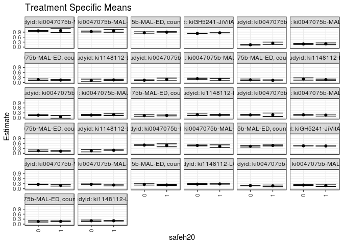

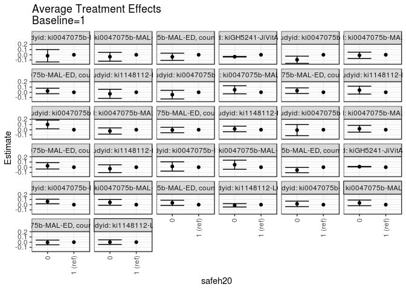

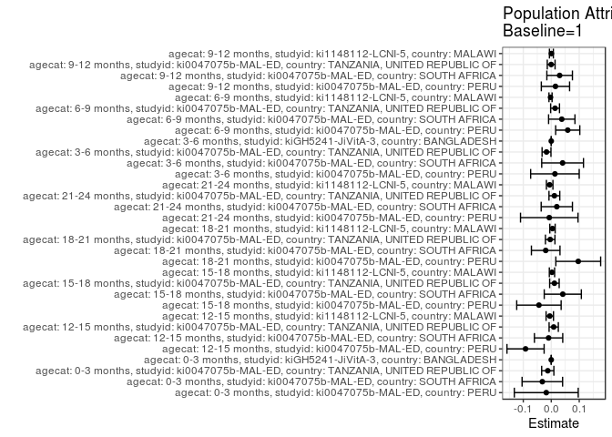

## Results Table

### Parameter: TSM

| agecat | studyid | country | intervention_level | baseline_level | estimate | ci_lower | ci_upper |
| --- | --- | --- | --- | --- | --- | --- | --- |
| 0-3 months | ki0047075b-MAL-ED | PERU | 1 | NA | 0.9926884 | 0.8774446 | 1.1079322 |
| 0-3 months | ki0047075b-MAL-ED | PERU | 0 | NA | 0.9737767 | 0.9463813 | 1.0011720 |
| 0-3 months | ki0047075b-MAL-ED | SOUTH AFRICA | 1 | NA | 0.9735020 | 0.8932685 | 1.0537355 |
| 0-3 months | ki0047075b-MAL-ED | SOUTH AFRICA | 0 | NA | 0.9353601 | 0.9058039 | 0.9649164 |
| 0-3 months | ki0047075b-MAL-ED | TANZANIA, UNITED REPUBLIC OF | 1 | NA | 0.8985696 | 0.8630127 | 0.9341265 |
| 0-3 months | ki0047075b-MAL-ED | TANZANIA, UNITED REPUBLIC OF | 0 | NA | 0.8595864 | 0.8007321 | 0.9184407 |
| 0-3 months | kiGH5241-JiVitA-3 | BANGLADESH | 1 | NA | 0.8577546 | 0.8546705 | 0.8608387 |
| 0-3 months | kiGH5241-JiVitA-3 | BANGLADESH | 0 | NA | 0.8205127 | 0.8162772 | 0.8247482 |
| 3-6 months | ki0047075b-MAL-ED | PERU | 1 | NA | 0.4817240 | 0.3941742 | 0.5692739 |
| 3-6 months | ki0047075b-MAL-ED | PERU | 0 | NA | 0.4958517 | 0.4757455 | 0.5159579 |
| 3-6 months | ki0047075b-MAL-ED | SOUTH AFRICA | 1 | NA | 0.4263275 | 0.3434109 | 0.5092441 |
| 3-6 months | ki0047075b-MAL-ED | SOUTH AFRICA | 0 | NA | 0.4735818 | 0.4466841 | 0.5004795 |
| 3-6 months | ki0047075b-MAL-ED | TANZANIA, UNITED REPUBLIC OF | 1 | NA | 0.4736562 | 0.4430833 | 0.5042290 |
| 3-6 months | ki0047075b-MAL-ED | TANZANIA, UNITED REPUBLIC OF | 0 | NA | 0.4183322 | 0.3786807 | 0.4579837 |
| 3-6 months | kiGH5241-JiVitA-3 | BANGLADESH | 1 | NA | 0.4413841 | 0.4383459 | 0.4444223 |
| 3-6 months | kiGH5241-JiVitA-3 | BANGLADESH | 0 | NA | 0.4515764 | 0.4487019 | 0.4544508 |
| 6-9 months | ki0047075b-MAL-ED | PERU | 1 | NA | 0.2004141 | 0.1586554 | 0.2421729 |
| 6-9 months | ki0047075b-MAL-ED | PERU | 0 | NA | 0.2619480 | 0.2456522 | 0.2782438 |
| 6-9 months | ki0047075b-MAL-ED | SOUTH AFRICA | 1 | NA | 0.2219947 | 0.1717232 | 0.2722663 |
| 6-9 months | ki0047075b-MAL-ED | SOUTH AFRICA | 0 | NA | 0.2664013 | 0.2430645 | 0.2897381 |
| 6-9 months | ki0047075b-MAL-ED | TANZANIA, UNITED REPUBLIC OF | 1 | NA | 0.2241638 | 0.1938523 | 0.2544754 |
| 6-9 months | ki0047075b-MAL-ED | TANZANIA, UNITED REPUBLIC OF | 0 | NA | 0.2593000 | 0.2198704 | 0.2987296 |
| 6-9 months | ki1148112-LCNI-5 | MALAWI | 1 | NA | 0.2875151 | 0.2735759 | 0.3014543 |
| 6-9 months | ki1148112-LCNI-5 | MALAWI | 0 | NA | 0.2757881 | 0.2462894 | 0.3052869 |
| 9-12 months | ki0047075b-MAL-ED | PERU | 1 | NA | 0.1723232 | 0.1222520 | 0.2223945 |
| 9-12 months | ki0047075b-MAL-ED | PERU | 0 | NA | 0.1879670 | 0.1717185 | 0.2042154 |
| 9-12 months | ki0047075b-MAL-ED | SOUTH AFRICA | 1 | NA | 0.1853412 | 0.1371966 | 0.2334857 |
| 9-12 months | ki0047075b-MAL-ED | SOUTH AFRICA | 0 | NA | 0.2197091 | 0.1949510 | 0.2444672 |
| 9-12 months | ki0047075b-MAL-ED | TANZANIA, UNITED REPUBLIC OF | 1 | NA | 0.1673880 | 0.1429536 | 0.1918224 |
| 9-12 months | ki0047075b-MAL-ED | TANZANIA, UNITED REPUBLIC OF | 0 | NA | 0.1616764 | 0.1243222 | 0.1990306 |
| 9-12 months | ki1148112-LCNI-5 | MALAWI | 1 | NA | 0.2017393 | 0.1842063 | 0.2192723 |
| 9-12 months | ki1148112-LCNI-5 | MALAWI | 0 | NA | 0.2019527 | 0.1613623 | 0.2425431 |
| 12-15 months | ki0047075b-MAL-ED | PERU | 1 | NA | 0.2334736 | 0.1667517 | 0.3001954 |
| 12-15 months | ki0047075b-MAL-ED | PERU | 0 | NA | 0.1379933 | 0.1206783 | 0.1553083 |
| 12-15 months | ki0047075b-MAL-ED | SOUTH AFRICA | 1 | NA | 0.1975646 | 0.1452742 | 0.2498549 |
| 12-15 months | ki0047075b-MAL-ED | SOUTH AFRICA | 0 | NA | 0.1874382 | 0.1589222 | 0.2159541 |
| 12-15 months | ki0047075b-MAL-ED | TANZANIA, UNITED REPUBLIC OF | 1 | NA | 0.1503263 | 0.1200622 | 0.1805905 |
| 12-15 months | ki0047075b-MAL-ED | TANZANIA, UNITED REPUBLIC OF | 0 | NA | 0.1745123 | 0.1312511 | 0.2177735 |
| 12-15 months | ki1148112-LCNI-5 | MALAWI | 1 | NA | 0.1571372 | 0.1195664 | 0.1947080 |
| 12-15 months | ki1148112-LCNI-5 | MALAWI | 0 | NA | 0.1271330 | 0.0480190 | 0.2062470 |
| 15-18 months | ki0047075b-MAL-ED | PERU | 1 | NA | 0.1874214 | 0.1072172 | 0.2676256 |
| 15-18 months | ki0047075b-MAL-ED | PERU | 0 | NA | 0.1415552 | 0.1218013 | 0.1613092 |
| 15-18 months | ki0047075b-MAL-ED | SOUTH AFRICA | 1 | NA | 0.1814782 | 0.1099776 | 0.2529789 |
| 15-18 months | ki0047075b-MAL-ED | SOUTH AFRICA | 0 | NA | 0.2292203 | 0.1981074 | 0.2603332 |
| 15-18 months | ki0047075b-MAL-ED | TANZANIA, UNITED REPUBLIC OF | 1 | NA | 0.1336456 | 0.1080887 | 0.1592025 |
| 15-18 months | ki0047075b-MAL-ED | TANZANIA, UNITED REPUBLIC OF | 0 | NA | 0.1637670 | 0.1170557 | 0.2104784 |
| 15-18 months | ki1148112-LCNI-5 | MALAWI | 1 | NA | 0.1712929 | 0.1363404 | 0.2062455 |
| 15-18 months | ki1148112-LCNI-5 | MALAWI | 0 | NA | 0.2126287 | 0.1449998 | 0.2802577 |
| 18-21 months | ki0047075b-MAL-ED | PERU | 1 | NA | 0.0653975 | -0.0157629 | 0.1465580 |
| 18-21 months | ki0047075b-MAL-ED | PERU | 0 | NA | 0.1660201 | 0.1463857 | 0.1856545 |
| 18-21 months | ki0047075b-MAL-ED | SOUTH AFRICA | 1 | NA | 0.1953761 | 0.1447067 | 0.2460455 |
| 18-21 months | ki0047075b-MAL-ED | SOUTH AFRICA | 0 | NA | 0.1705341 | 0.1404117 | 0.2006564 |
| 18-21 months | ki0047075b-MAL-ED | TANZANIA, UNITED REPUBLIC OF | 1 | NA | 0.1472590 | 0.1177243 | 0.1767938 |
| 18-21 months | ki0047075b-MAL-ED | TANZANIA, UNITED REPUBLIC OF | 0 | NA | 0.1421187 | 0.0987240 | 0.1855134 |
| 18-21 months | ki1148112-LCNI-5 | MALAWI | 1 | NA | 0.1774462 | 0.1548849 | 0.2000075 |
| 18-21 months | ki1148112-LCNI-5 | MALAWI | 0 | NA | 0.1926681 | 0.1449065 | 0.2404297 |
| 21-24 months | ki0047075b-MAL-ED | PERU | 1 | NA | 0.1869388 | 0.0820127 | 0.2918650 |
| 21-24 months | ki0047075b-MAL-ED | PERU | 0 | NA | 0.1795172 | 0.1591318 | 0.1999026 |
| 21-24 months | ki0047075b-MAL-ED | SOUTH AFRICA | 1 | NA | 0.1679950 | 0.1086901 | 0.2272999 |
| 21-24 months | ki0047075b-MAL-ED | SOUTH AFRICA | 0 | NA | 0.1870612 | 0.1608924 | 0.2132300 |
| 21-24 months | ki0047075b-MAL-ED | TANZANIA, UNITED REPUBLIC OF | 1 | NA | 0.1290143 | 0.0955981 | 0.1624305 |
| 21-24 months | ki0047075b-MAL-ED | TANZANIA, UNITED REPUBLIC OF | 0 | NA | 0.1551791 | 0.1046055 | 0.2057528 |
| 21-24 months | ki1148112-LCNI-5 | MALAWI | 1 | NA | 0.1846098 | 0.1552921 | 0.2139275 |
| 21-24 months | ki1148112-LCNI-5 | MALAWI | 0 | NA | 0.1558875 | 0.0871668 | 0.2246082 |

### Parameter: E(Y)

| agecat | studyid | country | intervention_level | baseline_level | estimate | ci_lower | ci_upper |
| --- | --- | --- | --- | --- | --- | --- | --- |
| 0-3 months | ki0047075b-MAL-ED | PERU | NA | NA | 0.9748614 | 0.9482620 | 1.0014607 |
| 0-3 months | ki0047075b-MAL-ED | SOUTH AFRICA | NA | NA | 0.9415988 | 0.9136365 | 0.9695612 |
| 0-3 months | ki0047075b-MAL-ED | TANZANIA, UNITED REPUBLIC OF | NA | NA | 0.8861087 | 0.8555112 | 0.9167061 |
| 0-3 months | kiGH5241-JiVitA-3 | BANGLADESH | NA | NA | 0.8576858 | 0.8546736 | 0.8606979 |
| 3-6 months | ki0047075b-MAL-ED | PERU | NA | NA | 0.4948529 | 0.4753805 | 0.5143254 |
| 3-6 months | ki0047075b-MAL-ED | SOUTH AFRICA | NA | NA | 0.4668837 | 0.4408277 | 0.4929397 |
| 3-6 months | ki0047075b-MAL-ED | TANZANIA, UNITED REPUBLIC OF | NA | NA | 0.4566833 | 0.4325348 | 0.4808318 |
| 3-6 months | kiGH5241-JiVitA-3 | BANGLADESH | NA | NA | 0.4413913 | 0.4384220 | 0.4443605 |
| 6-9 months | ki0047075b-MAL-ED | PERU | NA | NA | 0.2593318 | 0.2435782 | 0.2750853 |
| 6-9 months | ki0047075b-MAL-ED | SOUTH AFRICA | NA | NA | 0.2596104 | 0.2384684 | 0.2807524 |
| 6-9 months | ki0047075b-MAL-ED | TANZANIA, UNITED REPUBLIC OF | NA | NA | 0.2377801 | 0.2136152 | 0.2619451 |
| 6-9 months | ki1148112-LCNI-5 | MALAWI | NA | NA | 0.2849079 | 0.2723110 | 0.2975048 |
| 9-12 months | ki0047075b-MAL-ED | PERU | NA | NA | 0.1873440 | 0.1716106 | 0.2030773 |
| 9-12 months | ki0047075b-MAL-ED | SOUTH AFRICA | NA | NA | 0.2153147 | 0.1931793 | 0.2374501 |
| 9-12 months | ki0047075b-MAL-ED | TANZANIA, UNITED REPUBLIC OF | NA | NA | 0.1670684 | 0.1467422 | 0.1873945 |
| 9-12 months | ki1148112-LCNI-5 | MALAWI | NA | NA | 0.2022567 | 0.1863082 | 0.2182053 |
| 12-15 months | ki0047075b-MAL-ED | PERU | NA | NA | 0.1415461 | 0.1245184 | 0.1585737 |
| 12-15 months | ki0047075b-MAL-ED | SOUTH AFRICA | NA | NA | 0.1879898 | 0.1627929 | 0.2131868 |
| 12-15 months | ki0047075b-MAL-ED | TANZANIA, UNITED REPUBLIC OF | NA | NA | 0.1591083 | 0.1343053 | 0.1839113 |
| 12-15 months | ki1148112-LCNI-5 | MALAWI | NA | NA | 0.1518822 | 0.1181702 | 0.1855942 |
| 15-18 months | ki0047075b-MAL-ED | PERU | NA | NA | 0.1433364 | 0.1240576 | 0.1626152 |
| 15-18 months | ki0047075b-MAL-ED | SOUTH AFRICA | NA | NA | 0.2227120 | 0.1942678 | 0.2511562 |
| 15-18 months | ki0047075b-MAL-ED | TANZANIA, UNITED REPUBLIC OF | NA | NA | 0.1449507 | 0.1222652 | 0.1676362 |
| 15-18 months | ki1148112-LCNI-5 | MALAWI | NA | NA | 0.1738706 | 0.1423337 | 0.2054074 |
| 18-21 months | ki0047075b-MAL-ED | PERU | NA | NA | 0.1619131 | 0.1425878 | 0.1812383 |
| 18-21 months | ki0047075b-MAL-ED | SOUTH AFRICA | NA | NA | 0.1755205 | 0.1490254 | 0.2020155 |
| 18-21 months | ki0047075b-MAL-ED | TANZANIA, UNITED REPUBLIC OF | NA | NA | 0.1434559 | 0.1191029 | 0.1678089 |
| 18-21 months | ki1148112-LCNI-5 | MALAWI | NA | NA | 0.1818489 | 0.1616805 | 0.2020172 |
| 21-24 months | ki0047075b-MAL-ED | PERU | NA | NA | 0.1798026 | 0.1597891 | 0.1998162 |
| 21-24 months | ki0047075b-MAL-ED | SOUTH AFRICA | NA | NA | 0.1878453 | 0.1639966 | 0.2116939 |
| 21-24 months | ki0047075b-MAL-ED | TANZANIA, UNITED REPUBLIC OF | NA | NA | 0.1402078 | 0.1124924 | 0.1679233 |
| 21-24 months | ki1148112-LCNI-5 | MALAWI | NA | NA | 0.1789517 | 0.1520986 | 0.2058049 |

### Parameter: ATE

| agecat | studyid | country | intervention_level | baseline_level | estimate | ci_lower | ci_upper |
| --- | --- | --- | --- | --- | --- | --- | --- |
| 0-3 months | ki0047075b-MAL-ED | PERU | 1 | 1 | 0.0000000 | 0.0000000 | 0.0000000 |
| 0-3 months | ki0047075b-MAL-ED | PERU | 0 | 1 | -0.0189117 | -0.1373052 | 0.0994818 |
| 0-3 months | ki0047075b-MAL-ED | SOUTH AFRICA | 1 | 1 | 0.0000000 | 0.0000000 | 0.0000000 |
| 0-3 months | ki0047075b-MAL-ED | SOUTH AFRICA | 0 | 1 | -0.0381419 | -0.1236606 | 0.0473769 |
| 0-3 months | ki0047075b-MAL-ED | TANZANIA, UNITED REPUBLIC OF | 1 | 1 | 0.0000000 | 0.0000000 | 0.0000000 |
| 0-3 months | ki0047075b-MAL-ED | TANZANIA, UNITED REPUBLIC OF | 0 | 1 | -0.0389832 | -0.1078080 | 0.0298415 |
| 0-3 months | kiGH5241-JiVitA-3 | BANGLADESH | 1 | 1 | 0.0000000 | 0.0000000 | 0.0000000 |
| 0-3 months | kiGH5241-JiVitA-3 | BANGLADESH | 0 | 1 | -0.0372419 | -0.0423858 | -0.0320980 |
| 3-6 months | ki0047075b-MAL-ED | PERU | 1 | 1 | 0.0000000 | 0.0000000 | 0.0000000 |
| 3-6 months | ki0047075b-MAL-ED | PERU | 0 | 1 | 0.0141277 | -0.0756281 | 0.1038834 |
| 3-6 months | ki0047075b-MAL-ED | SOUTH AFRICA | 1 | 1 | 0.0000000 | 0.0000000 | 0.0000000 |
| 3-6 months | ki0047075b-MAL-ED | SOUTH AFRICA | 0 | 1 | 0.0472543 | -0.0398514 | 0.1343600 |
| 3-6 months | ki0047075b-MAL-ED | TANZANIA, UNITED REPUBLIC OF | 1 | 1 | 0.0000000 | 0.0000000 | 0.0000000 |
| 3-6 months | ki0047075b-MAL-ED | TANZANIA, UNITED REPUBLIC OF | 0 | 1 | -0.0553240 | -0.1055846 | -0.0050633 |
| 3-6 months | kiGH5241-JiVitA-3 | BANGLADESH | 1 | 1 | 0.0000000 | 0.0000000 | 0.0000000 |
| 3-6 months | kiGH5241-JiVitA-3 | BANGLADESH | 0 | 1 | 0.0101923 | 0.0061831 | 0.0142015 |
| 6-9 months | ki0047075b-MAL-ED | PERU | 1 | 1 | 0.0000000 | 0.0000000 | 0.0000000 |
| 6-9 months | ki0047075b-MAL-ED | PERU | 0 | 1 | 0.0615339 | 0.0167617 | 0.1063061 |
| 6-9 months | ki0047075b-MAL-ED | SOUTH AFRICA | 1 | 1 | 0.0000000 | 0.0000000 | 0.0000000 |
| 6-9 months | ki0047075b-MAL-ED | SOUTH AFRICA | 0 | 1 | 0.0444066 | -0.0110875 | 0.0999006 |
| 6-9 months | ki0047075b-MAL-ED | TANZANIA, UNITED REPUBLIC OF | 1 | 1 | 0.0000000 | 0.0000000 | 0.0000000 |
| 6-9 months | ki0047075b-MAL-ED | TANZANIA, UNITED REPUBLIC OF | 0 | 1 | 0.0351362 | -0.0149794 | 0.0852518 |
| 6-9 months | ki1148112-LCNI-5 | MALAWI | 1 | 1 | 0.0000000 | 0.0000000 | 0.0000000 |
| 6-9 months | ki1148112-LCNI-5 | MALAWI | 0 | 1 | -0.0117270 | -0.0443887 | 0.0209347 |
| 9-12 months | ki0047075b-MAL-ED | PERU | 1 | 1 | 0.0000000 | 0.0000000 | 0.0000000 |
| 9-12 months | ki0047075b-MAL-ED | PERU | 0 | 1 | 0.0156437 | -0.0369979 | 0.0682854 |
| 9-12 months | ki0047075b-MAL-ED | SOUTH AFRICA | 1 | 1 | 0.0000000 | 0.0000000 | 0.0000000 |
| 9-12 months | ki0047075b-MAL-ED | SOUTH AFRICA | 0 | 1 | 0.0343680 | -0.0198454 | 0.0885813 |
| 9-12 months | ki0047075b-MAL-ED | TANZANIA, UNITED REPUBLIC OF | 1 | 1 | 0.0000000 | 0.0000000 | 0.0000000 |
| 9-12 months | ki0047075b-MAL-ED | TANZANIA, UNITED REPUBLIC OF | 0 | 1 | -0.0057116 | -0.0504499 | 0.0390267 |
| 9-12 months | ki1148112-LCNI-5 | MALAWI | 1 | 1 | 0.0000000 | 0.0000000 | 0.0000000 |
| 9-12 months | ki1148112-LCNI-5 | MALAWI | 0 | 1 | 0.0002134 | -0.0441006 | 0.0445274 |
| 12-15 months | ki0047075b-MAL-ED | PERU | 1 | 1 | 0.0000000 | 0.0000000 | 0.0000000 |
| 12-15 months | ki0047075b-MAL-ED | PERU | 0 | 1 | -0.0954802 | -0.1644122 | -0.0265483 |
| 12-15 months | ki0047075b-MAL-ED | SOUTH AFRICA | 1 | 1 | 0.0000000 | 0.0000000 | 0.0000000 |
| 12-15 months | ki0047075b-MAL-ED | SOUTH AFRICA | 0 | 1 | -0.0101264 | -0.0702232 | 0.0499703 |
| 12-15 months | ki0047075b-MAL-ED | TANZANIA, UNITED REPUBLIC OF | 1 | 1 | 0.0000000 | 0.0000000 | 0.0000000 |
| 12-15 months | ki0047075b-MAL-ED | TANZANIA, UNITED REPUBLIC OF | 0 | 1 | 0.0241859 | -0.0285191 | 0.0768909 |
| 12-15 months | ki1148112-LCNI-5 | MALAWI | 1 | 1 | 0.0000000 | 0.0000000 | 0.0000000 |
| 12-15 months | ki1148112-LCNI-5 | MALAWI | 0 | 1 | -0.0300042 | -0.1176659 | 0.0576575 |
| 15-18 months | ki0047075b-MAL-ED | PERU | 1 | 1 | 0.0000000 | 0.0000000 | 0.0000000 |
| 15-18 months | ki0047075b-MAL-ED | PERU | 0 | 1 | -0.0458662 | -0.1284672 | 0.0367349 |
| 15-18 months | ki0047075b-MAL-ED | SOUTH AFRICA | 1 | 1 | 0.0000000 | 0.0000000 | 0.0000000 |
| 15-18 months | ki0047075b-MAL-ED | SOUTH AFRICA | 0 | 1 | 0.0477421 | -0.0304565 | 0.1259406 |
| 15-18 months | ki0047075b-MAL-ED | TANZANIA, UNITED REPUBLIC OF | 1 | 1 | 0.0000000 | 0.0000000 | 0.0000000 |
| 15-18 months | ki0047075b-MAL-ED | TANZANIA, UNITED REPUBLIC OF | 0 | 1 | 0.0301214 | -0.0232697 | 0.0835126 |
| 15-18 months | ki1148112-LCNI-5 | MALAWI | 1 | 1 | 0.0000000 | 0.0000000 | 0.0000000 |
| 15-18 months | ki1148112-LCNI-5 | MALAWI | 0 | 1 | 0.0413358 | -0.0344614 | 0.1171329 |
| 18-21 months | ki0047075b-MAL-ED | PERU | 1 | 1 | 0.0000000 | 0.0000000 | 0.0000000 |
| 18-21 months | ki0047075b-MAL-ED | PERU | 0 | 1 | 0.1006226 | 0.0171209 | 0.1841242 |
| 18-21 months | ki0047075b-MAL-ED | SOUTH AFRICA | 1 | 1 | 0.0000000 | 0.0000000 | 0.0000000 |
| 18-21 months | ki0047075b-MAL-ED | SOUTH AFRICA | 0 | 1 | -0.0248420 | -0.0846906 | 0.0350066 |
| 18-21 months | ki0047075b-MAL-ED | TANZANIA, UNITED REPUBLIC OF | 1 | 1 | 0.0000000 | 0.0000000 | 0.0000000 |
| 18-21 months | ki0047075b-MAL-ED | TANZANIA, UNITED REPUBLIC OF | 0 | 1 | -0.0051403 | -0.0579868 | 0.0477062 |
| 18-21 months | ki1148112-LCNI-5 | MALAWI | 1 | 1 | 0.0000000 | 0.0000000 | 0.0000000 |
| 18-21 months | ki1148112-LCNI-5 | MALAWI | 0 | 1 | 0.0152219 | -0.0379125 | 0.0683563 |
| 21-24 months | ki0047075b-MAL-ED | PERU | 1 | 1 | 0.0000000 | 0.0000000 | 0.0000000 |
| 21-24 months | ki0047075b-MAL-ED | PERU | 0 | 1 | -0.0074216 | -0.1143097 | 0.0994665 |
| 21-24 months | ki0047075b-MAL-ED | SOUTH AFRICA | 1 | 1 | 0.0000000 | 0.0000000 | 0.0000000 |
| 21-24 months | ki0047075b-MAL-ED | SOUTH AFRICA | 0 | 1 | 0.0190662 | -0.0457149 | 0.0838473 |
| 21-24 months | ki0047075b-MAL-ED | TANZANIA, UNITED REPUBLIC OF | 1 | 1 | 0.0000000 | 0.0000000 | 0.0000000 |
| 21-24 months | ki0047075b-MAL-ED | TANZANIA, UNITED REPUBLIC OF | 0 | 1 | 0.0261648 | -0.0344884 | 0.0868180 |
| 21-24 months | ki1148112-LCNI-5 | MALAWI | 1 | 1 | 0.0000000 | 0.0000000 | 0.0000000 |
| 21-24 months | ki1148112-LCNI-5 | MALAWI | 0 | 1 | -0.0287223 | -0.1035412 | 0.0460966 |

### Parameter: PAR

| agecat | studyid | country | intervention_level | baseline_level | estimate | ci_lower | ci_upper |
| --- | --- | --- | --- | --- | --- | --- | --- |
| 0-3 months | ki0047075b-MAL-ED | PERU | 1 | NA | -0.0178270 | -0.1320603 | 0.0964062 |
| 0-3 months | ki0047075b-MAL-ED | SOUTH AFRICA | 1 | NA | -0.0319032 | -0.1043553 | 0.0405490 |
| 0-3 months | ki0047075b-MAL-ED | TANZANIA, UNITED REPUBLIC OF | 1 | NA | -0.0124609 | -0.0342696 | 0.0093477 |
| 0-3 months | kiGH5241-JiVitA-3 | BANGLADESH | 1 | NA | -0.0000688 | -0.0001979 | 0.0000603 |
| 3-6 months | ki0047075b-MAL-ED | PERU | 1 | NA | 0.0131289 | -0.0736720 | 0.0999299 |
| 3-6 months | ki0047075b-MAL-ED | SOUTH AFRICA | 1 | NA | 0.0405562 | -0.0341183 | 0.1152306 |
| 3-6 months | ki0047075b-MAL-ED | TANZANIA, UNITED REPUBLIC OF | 1 | NA | -0.0169729 | -0.0328725 | -0.0010733 |
| 3-6 months | kiGH5241-JiVitA-3 | BANGLADESH | 1 | NA | 0.0000072 | -0.0000911 | 0.0001055 |
| 6-9 months | ki0047075b-MAL-ED | PERU | 1 | NA | 0.0589176 | 0.0157434 | 0.1020919 |
| 6-9 months | ki0047075b-MAL-ED | SOUTH AFRICA | 1 | NA | 0.0376157 | -0.0095036 | 0.0847349 |
| 6-9 months | ki0047075b-MAL-ED | TANZANIA, UNITED REPUBLIC OF | 1 | NA | 0.0136163 | -0.0022169 | 0.0294495 |
| 6-9 months | ki1148112-LCNI-5 | MALAWI | 1 | NA | -0.0026072 | -0.0081639 | 0.0029495 |
| 9-12 months | ki0047075b-MAL-ED | PERU | 1 | NA | 0.0150207 | -0.0355261 | 0.0655676 |
| 9-12 months | ki0047075b-MAL-ED | SOUTH AFRICA | 1 | NA | 0.0299735 | -0.0157492 | 0.0756962 |
| 9-12 months | ki0047075b-MAL-ED | TANZANIA, UNITED REPUBLIC OF | 1 | NA | -0.0003196 | -0.0142467 | 0.0136075 |
| 9-12 months | ki1148112-LCNI-5 | MALAWI | 1 | NA | 0.0005174 | -0.0064752 | 0.0075100 |
| 12-15 months | ki0047075b-MAL-ED | PERU | 1 | NA | -0.0919275 | -0.1583387 | -0.0255163 |
| 12-15 months | ki0047075b-MAL-ED | SOUTH AFRICA | 1 | NA | -0.0095748 | -0.0602001 | 0.0410506 |
| 12-15 months | ki0047075b-MAL-ED | TANZANIA, UNITED REPUBLIC OF | 1 | NA | 0.0087819 | -0.0077030 | 0.0252668 |
| 12-15 months | ki1148112-LCNI-5 | MALAWI | 1 | NA | -0.0052550 | -0.0184810 | 0.0079709 |
| 15-18 months | ki0047075b-MAL-ED | PERU | 1 | NA | -0.0440850 | -0.1234875 | 0.0353175 |
| 15-18 months | ki0047075b-MAL-ED | SOUTH AFRICA | 1 | NA | 0.0412338 | -0.0251118 | 0.1075794 |
| 15-18 months | ki0047075b-MAL-ED | TANZANIA, UNITED REPUBLIC OF | 1 | NA | 0.0113051 | -0.0057183 | 0.0283286 |
| 15-18 months | ki1148112-LCNI-5 | MALAWI | 1 | NA | 0.0025776 | -0.0068693 | 0.0120246 |
| 18-21 months | ki0047075b-MAL-ED | PERU | 1 | NA | 0.0965155 | 0.0163734 | 0.1766577 |
| 18-21 months | ki0047075b-MAL-ED | SOUTH AFRICA | 1 | NA | -0.0198556 | -0.0709266 | 0.0312154 |
| 18-21 months | ki0047075b-MAL-ED | TANZANIA, UNITED REPUBLIC OF | 1 | NA | -0.0038031 | -0.0207994 | 0.0131932 |
| 18-21 months | ki1148112-LCNI-5 | MALAWI | 1 | NA | 0.0044027 | -0.0051584 | 0.0139638 |
| 21-24 months | ki0047075b-MAL-ED | PERU | 1 | NA | -0.0071362 | -0.1099134 | 0.0956410 |
| 21-24 months | ki0047075b-MAL-ED | SOUTH AFRICA | 1 | NA | 0.0198502 | -0.0360346 | 0.0757350 |
| 21-24 months | ki0047075b-MAL-ED | TANZANIA, UNITED REPUBLIC OF | 1 | NA | 0.0111935 | -0.0081081 | 0.0304950 |
| 21-24 months | ki1148112-LCNI-5 | MALAWI | 1 | NA | -0.0056580 | -0.0172851 | 0.0059691 |